# ZeroAccess rootkit Analysis

## Requerimientos

Configura el `working directory` con el path donde tienes guardado este archivo. Puedes hacerlo desde el menu “Session” -> “Set working directory” -> “To files pane location” o ejecutando el siguiente código en el terminal cambiando `<LOCAL_PATH>`:

`setwd(<LOCAL_PATH>/code/examples/zeroAccess)`

## Resumen

Este informe realiza un analisis centrado en el estudio de las conexiones del malware ZeroAccess rootkit.

A partir de los datos obtenidos de Symantec durante un periodo de 24 horas durante el mes de Julio del 2013 vamos a realizar un análisis de la información para intentar resolver dudas. Concretamente se quiere conocer la respuesta a las siguientes preguntas:

- ¿Como se distribuye geográficamente el malware ZeroAccess?
- ¿Se puede extraer alguna deducción de su distribución?
- ¿Que tipo de clientes son más susceptibles a ser infectados?

## Análisis

Representando esta información con un gráfico de dispersión podemos ver que la distribución se asemeja notablemente al mapamundi:

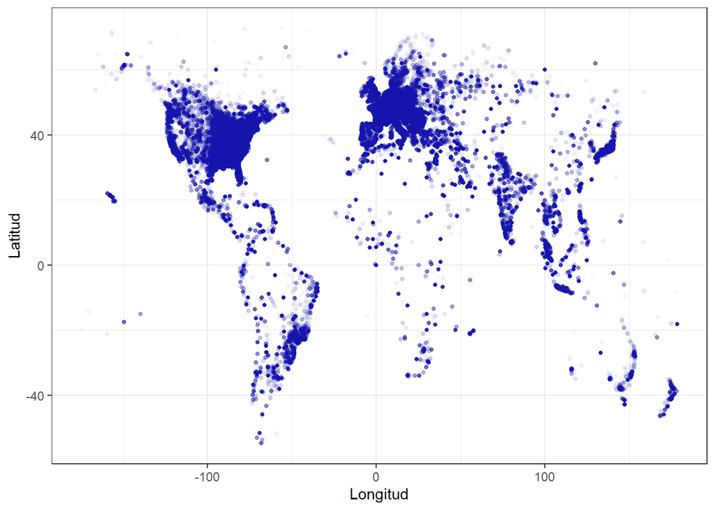

Con esta representación se puede identificar que la mayor concentración de infecciones ocurren en la mayor parte de Europa, la costa este de EEUU y en menor grado en Japón y otros puntos del planeta.  
Añadimos información sobre paises y sus fronteras para enriquecer el mapa.

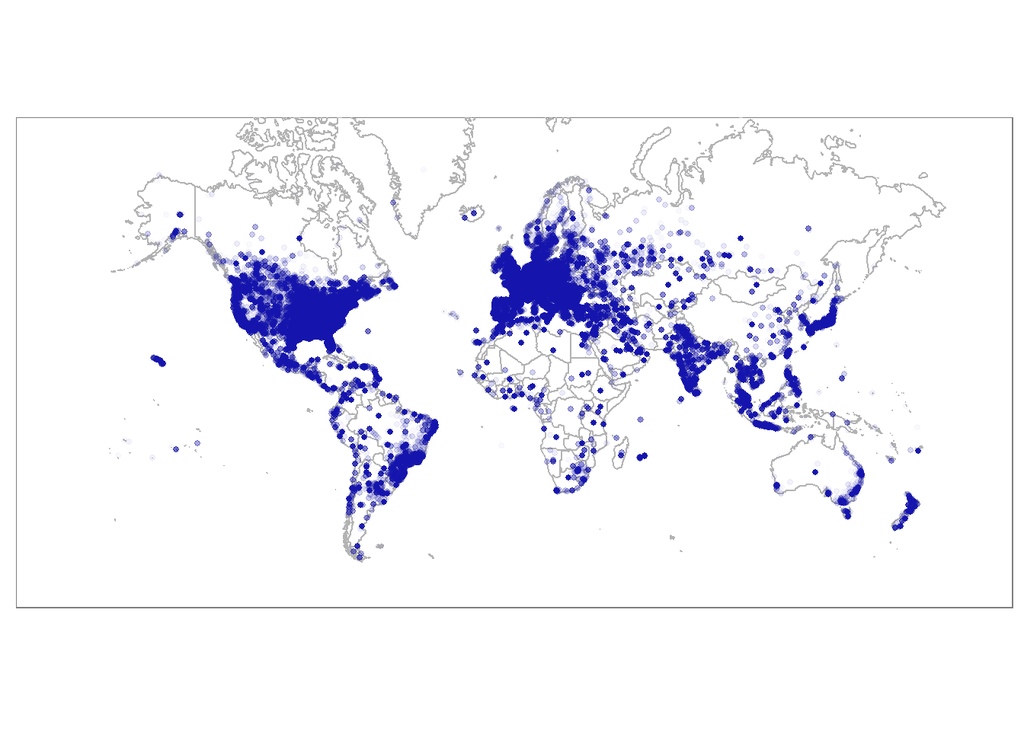

Ahora tenemos una representación real de las conexiones de la botnet, pero seguimos sin poder decir mucho más que el malware ZeroAccess tiene un alcance internacional.  
Vamos a ver la distribución en función de los paises afectados. Para ello usaremos un mapa de tipo *choropleth*, que básicamente significa pintar los paises con colores.

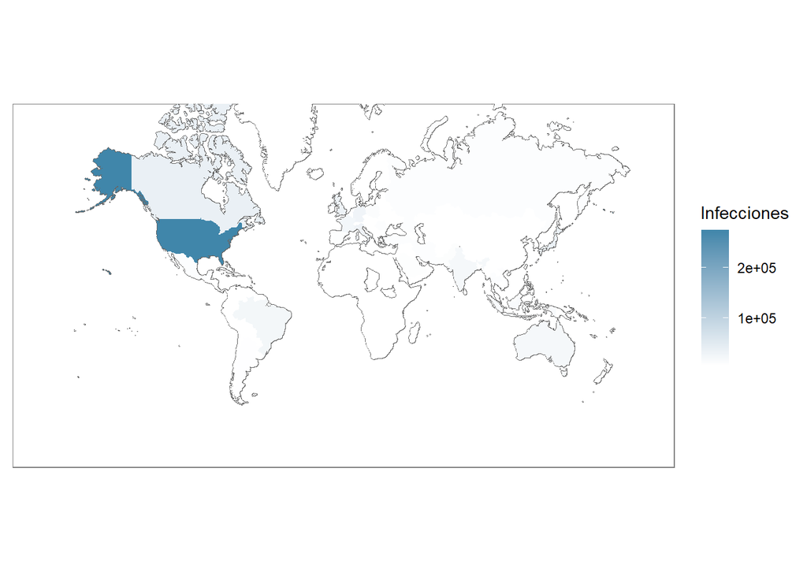

En este punto podemos decir que la mayoria de las infeciones se encuentran en EEUU. Esto no lo podriamos haber deducido con los anteriores mapas. Para ver con más detalle la diferencia entre paises, mostramos la distribución en función del porcentaje de infecciones de cada pais (top10):

```
##        region  count  perc
## 205       USA 275333 35.43
## 35     Canada  35904  4.62
## 93      Japan  34313  4.42
## 201        UK  32270  4.15
## 90      Italy  29344  3.78
## 68    Germany  27442  3.53
## 28     Brazil  22517  2.90
## 63     France  21910  2.82
## 11  Australia  19186  2.47
## 83      India  19074  2.45
```

### Análisis de las infecciones en EEUU

Visto que la mayoria de infecciones se producen en EEUU, vamos a enfocar el análisis en intentar encontrar alguna relación. Primero, veámos como se distribuyen las infecciones a lo largo y ancho del territorio.  
Es necesario reducir el conjunto de datos al subconjunto que pertenece a EEUU, sinó las representaciones seguirian siendo de todo el mundo.

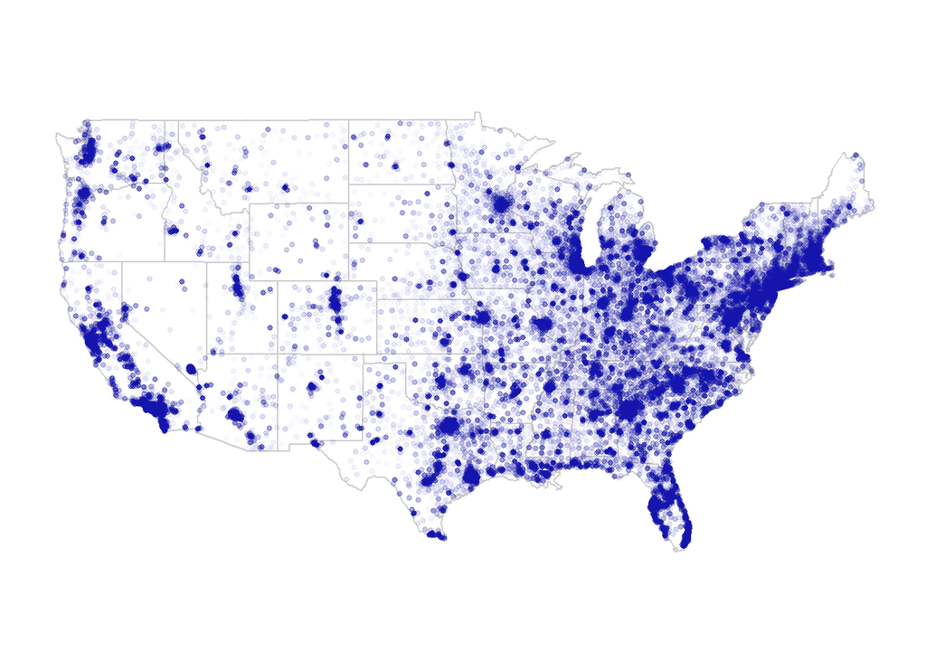

Viendo el resultado, parece una distribución de la población. Para ello vamos a realizar un mapa coloreando los estados en función de la densidad de infecciones. Hay que tener en cuenta que los servicios de geolocalización no llegan siempre a detectar más detalle que el pais. En esos casos las coordenadas que devuelve son las del “centro” del pais. En el caso de EEUU este punto se encuentra en Potwin, Kansas. Para la siguiente representación se eliminaran estos casos.

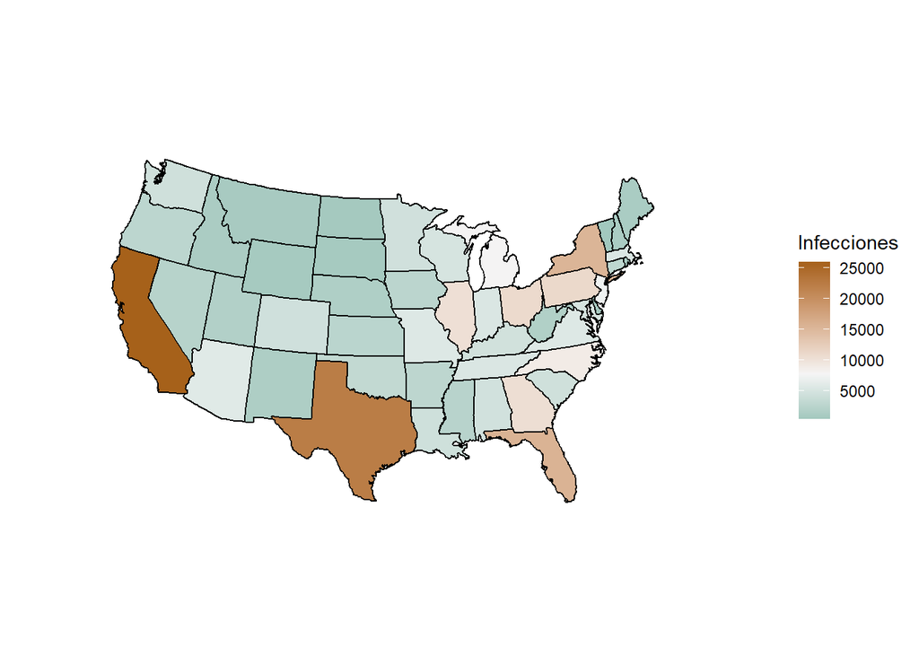

Viendo el mapa, podemos identificar que la mayor parte de las infecciones se encuentran en California, Texas, Florida y New York… justamente los estados más poblados de EEUU. En otras palabras, estamos viendo un reflejo de la densidad de población a partir de las infecciones de la botnet Zero Access. Es necesario **normalizar** los datos para responder preguntas del tipo:

- ¿Cuanta gente afectada hay por infección?
- ¿Qué proporción de población esta infectada?
- ¿Cuantas infecciones hay por cada 1000 habitantes?

Para resolver estas preguntas y profundizar en el analisis, cruzaremos la información con los datos públicos sobre población de [EEUU](http://www.internetworldstats.com/stats26.htm).

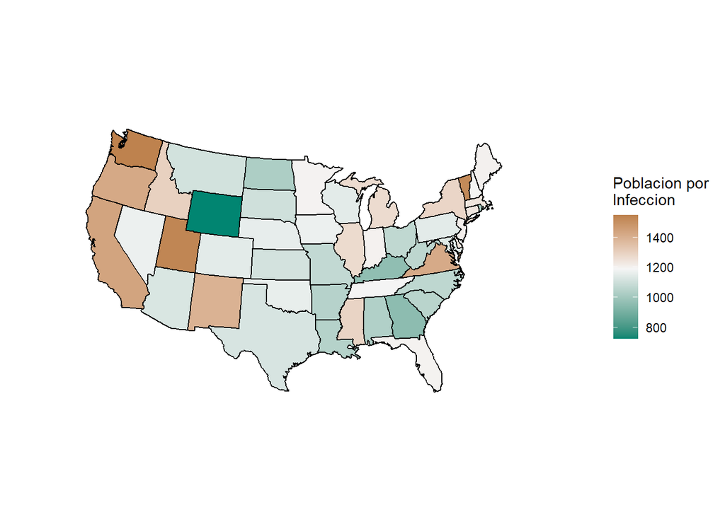

Con esta representación normalizada, se puede identificar que el estado de Wyoming es el que tiene más infecciones por habitante.

Para responder preguntas sobre que tipo de clientes son más susceptibles a ser infectados, habría que cruzar la información que ya tenemos con otra del tipo: ingresos medios, estudios, etc.